# UN Hackthon on Data Science

Team Name: Isonga DS Team

Team Members: 1. NIYITEGEKA Janvier, 2. NKIRANUYE Sangwa, 3. MUKAMANA Florentine, 4. SINDIKUBWABO Emmanuel

Importing required Modules

```python
import warnings
import matplotlib.pyplot as plt
import pandas as pd
import seaborn as sns
import numpy as np
from sklearn.svm import SVR
from sklearn.tree import DecisionTreeRegressor
from sklearn.neighbors import KNeighborsRegressor
from sklearn.ensemble import GradientBoostingRegressor
from sklearn.ensemble import RandomForestRegressor
from sklearn.linear_model import LinearRegression
from sklearn.tree import DecisionTreeRegressor
from sklearn.metrics import accuracy_score,mean_squared_error,r2_score,mean_absolute_error
from math import sqrt

warnings.filterwarnings('ignore')
import pandas as pd
import numpy as np
import matplotlib.pyplot as plt
import numpy as np
from tensorflow.keras.models import Sequential
from tensorflow.keras.layers import LSTM
from tensorflow.keras.layers import Dense
from tensorflow.keras.layers import Flatten
from sklearn.model_selection import train_test_split

import matplotlib.pyplot as plt
import matplotlib
%matplotlib inline
```

# Importing dataset from local drive using Python Pandas library

```python
df=pd.read_csv('owid-covid-data.csv')
```

Data Source: https://github.com/owid/covid-19-data/blob/master/public/data/README.md

Displaying first 5 rows of the dataset

```python
df.head()
```

|  | iso_code | continent | location | date | total_cases | new_cases | new_cases_smoothed | total_deaths | new_deaths | new_deaths_smoothed | ... | female_smokers | male_smokers | handwashing_facilities | hospital_beds_per_thousand | life_expectancy | human_development_index | excess_mortality_cumulative_absolute | excess_mortality_cumulative | excess_mortality | excess_mortality_cumulative_per_million |
| --- | --- | --- | --- | --- | --- | --- | --- | --- | --- | --- | --- | --- | --- | --- | --- | --- | --- | --- | --- | --- | --- |
| 0 | AFG | Asia | Afghanistan | 2/24/2020 | 5.0 | 5.0 | NaN | NaN | NaN | NaN | ... | NaN | NaN | 37.746 | 0.5 | 64.83 | 0.511 | NaN | NaN | NaN | NaN |
| 1 | AFG | Asia | Afghanistan | 2/25/2020 | 5.0 | 0.0 | NaN | NaN | NaN | NaN | ... | NaN | NaN | 37.746 | 0.5 | 64.83 | 0.511 | NaN | NaN | NaN | NaN |
| 2 | AFG | Asia | Afghanistan | 2/26/2020 | 5.0 | 0.0 | NaN | NaN | NaN | NaN | ... | NaN | NaN | 37.746 | 0.5 | 64.83 | 0.511 | NaN | NaN | NaN | NaN |
| 3 | AFG | Asia | Afghanistan | 2/27/2020 | 5.0 | 0.0 | NaN | NaN | NaN | NaN | ... | NaN | NaN | 37.746 | 0.5 | 64.83 | 0.511 | NaN | NaN | NaN | NaN |
| 4 | AFG | Asia | Afghanistan | 2/28/2020 | 5.0 | 0.0 | NaN | NaN | NaN | NaN | ... | NaN | NaN | 37.746 | 0.5 | 64.83 | 0.511 | NaN | NaN | NaN | NaN |

5 rows × 67 columns

Displaying shape of the dataset

```python
df.shape
```

```
(138046, 67)
```

Displaying list of columns

```python
df.columns
```

```
Index(['iso_code', 'continent', 'location', 'date', 'total_cases', 'new_cases',
       'new_cases_smoothed', 'total_deaths', 'new_deaths',
       'new_deaths_smoothed', 'total_cases_per_million',
       'new_cases_per_million', 'new_cases_smoothed_per_million',
       'total_deaths_per_million', 'new_deaths_per_million',
       'new_deaths_smoothed_per_million', 'reproduction_rate', 'icu_patients',
       'icu_patients_per_million', 'hosp_patients',
       'hosp_patients_per_million', 'weekly_icu_admissions',
       'weekly_icu_admissions_per_million', 'weekly_hosp_admissions',
       'weekly_hosp_admissions_per_million', 'new_tests', 'total_tests',
       'total_tests_per_thousand', 'new_tests_per_thousand',
       'new_tests_smoothed', 'new_tests_smoothed_per_thousand',
       'positive_rate', 'tests_per_case', 'tests_units', 'total_vaccinations',
       'people_vaccinated', 'people_fully_vaccinated', 'total_boosters',
       'new_vaccinations', 'new_vaccinations_smoothed',
       'total_vaccinations_per_hundred', 'people_vaccinated_per_hundred',
       'people_fully_vaccinated_per_hundred', 'total_boosters_per_hundred',
       'new_vaccinations_smoothed_per_million',
       'new_people_vaccinated_smoothed',
       'new_people_vaccinated_smoothed_per_hundred', 'stringency_index',
       'population', 'population_density', 'median_age', 'aged_65_older',
       'aged_70_older', 'gdp_per_capita', 'extreme_poverty',
       'cardiovasc_death_rate', 'diabetes_prevalence', 'female_smokers',
       'male_smokers', 'handwashing_facilities', 'hospital_beds_per_thousand',
       'life_expectancy', 'human_development_index',
       'excess_mortality_cumulative_absolute', 'excess_mortality_cumulative',
       'excess_mortality', 'excess_mortality_cumulative_per_million'],
      dtype='object')
```

Selecting columns of interest

```python
columns=['continent', 'location', 'date', 'new_cases','total_cases', 'new_deaths', 'total_deaths','new_tests', 'people_vaccinated',
       'people_fully_vaccinated','population','population_density', 'median_age', 'aged_65_older',
       'aged_70_older','gdp_per_capita','cardiovasc_death_rate', 'diabetes_prevalence','human_development_index']
```

```python
df=df[columns]
```

Selecting african region

```python
df1=df[df['continent']=='Africa']
```

Listing Countries assessed

```python
df1['location'].unique()
```

```
array(['Algeria', 'Angola', 'Benin', 'Botswana', 'Burkina Faso',
       'Burundi', 'Cameroon', 'Cape Verde', 'Central African Republic',
       'Chad', 'Comoros', 'Congo', "Cote d'Ivoire",
       'Democratic Republic of Congo', 'Djibouti', 'Egypt',
       'Equatorial Guinea', 'Eritrea', 'Eswatini', 'Ethiopia', 'Gabon',
       'Gambia', 'Ghana', 'Guinea', 'Guinea-Bissau', 'Kenya', 'Lesotho',
       'Liberia', 'Libya', 'Madagascar', 'Malawi', 'Mali', 'Mauritania',
       'Mauritius', 'Morocco', 'Mozambique', 'Namibia', 'Niger',
       'Nigeria', 'Rwanda', 'Saint Helena', 'Sao Tome and Principe',
       'Senegal', 'Seychelles', 'Sierra Leone', 'Somalia', 'South Africa',
       'South Sudan', 'Sudan', 'Tanzania', 'Togo', 'Tunisia', 'Uganda',
       'Zambia', 'Zimbabwe'], dtype=object)
```

# Cleanning Dataset

Writing function to handle missing values in new_deaths, new_tests, new_cases,people_vaccinated, people_fully_vaccinated colums

```python
def fill_cols(col):
    cols=[0]
    for i in range(len(col)):
        if col.values[i]==' ':
            cols.append(cols[-1])
        else:
            cols.append(col.values[i])
    return cols
```

Writing function to handle missing values in total_cases and total_deaths columns

```python
def fill_cols2(col1,col2):
    new_col=[0]
    for i in range(len(col1)):
        if col1.values[i]==' ':
            new_col.append(col2.values[i]+new_col[-1])
        else:
            new_col.append(col1.values[i])
    return new_col
```

Cleanning the dataset based on location

```python
def clean_dataset(dataset):
    data=dataset[:0]
    for countr in dataset['location'].unique():
        dat=dataset[dataset['location']==countr].copy()
        dat['new_deaths']=dat['new_deaths'].fillna(value=0)
        dat['new_tests']=dat['new_tests'].fillna(value=0)
        dat['new_cases']=dat['new_cases'].fillna(value=0)

        dat['people_vaccinated']=dat['people_vaccinated'].fillna(value=' ')
        dat['people_vaccinated']=fill_cols(dat['people_vaccinated'])[1:]

        dat['people_fully_vaccinated']=dat['people_fully_vaccinated'].fillna(value=' ')
        dat['people_fully_vaccinated']=fill_cols(dat['people_fully_vaccinated'])[1:]

        dat['total_cases']=dat['total_cases'].fillna(value=' ')
        dat['total_deaths']=dat['total_deaths'].fillna(value=' ')

        dat['total_cases']=fill_cols2(dat['total_cases'],dat['new_cases'])[1:]
        dat['total_deaths']=fill_cols2(dat['total_deaths'],dat['new_deaths'])[1:]
        data=pd.concat([data,dat])

    return data
```

Displaying cleanned dataset

```python
dataset=clean_dataset(df1)
dataset
```

|  | continent | location | date | new_cases | total_cases | new_deaths | total_deaths | new_tests | people_vaccinated | people_fully_vaccinated | population | population_density | median_age | aged_65_older | aged_70_older | gdp_per_capita | cardiovasc_death_rate | diabetes_prevalence | human_development_index |
| --- | --- | --- | --- | --- | --- | --- | --- | --- | --- | --- | --- | --- | --- | --- | --- | --- | --- | --- | --- |
| 1963 | Africa | Algeria | 2/25/2020 | 1.0 | 1.0 | 0.0 | 0.0 | 0.0 | 0.0 | 0.0 | 44616626.0 | 17.348 | 29.1 | 6.211 | 3.857 | 13913.839 | 278.364 | 6.73 | 0.748 |
| 1964 | Africa | Algeria | 2/26/2020 | 0.0 | 1.0 | 0.0 | 0.0 | 0.0 | 0.0 | 0.0 | 44616626.0 | 17.348 | 29.1 | 6.211 | 3.857 | 13913.839 | 278.364 | 6.73 | 0.748 |
| 1965 | Africa | Algeria | 2/27/2020 | 0.0 | 1.0 | 0.0 | 0.0 | 0.0 | 0.0 | 0.0 | 44616626.0 | 17.348 | 29.1 | 6.211 | 3.857 | 13913.839 | 278.364 | 6.73 | 0.748 |
| 1966 | Africa | Algeria | 2/28/2020 | 0.0 | 1.0 | 0.0 | 0.0 | 0.0 | 0.0 | 0.0 | 44616626.0 | 17.348 | 29.1 | 6.211 | 3.857 | 13913.839 | 278.364 | 6.73 | 0.748 |
| 1967 | Africa | Algeria | 2/29/2020 | 0.0 | 1.0 | 0.0 | 0.0 | 0.0 | 0.0 | 0.0 | 44616626.0 | 17.348 | 29.1 | 6.211 | 3.857 | 13913.839 | 278.364 | 6.73 | 0.748 |
| ... | ... | ... | ... | ... | ... | ... | ... | ... | ... | ... | ... | ... | ... | ... | ... | ... | ... | ... | ... |
| 138041 | Africa | Zimbabwe | 12/1/2021 | 712.0 | 135337.0 | 0.0 | 4707.0 | 6148.0 | 3809900.0 | 2830540.0 | 15092171.0 | 42.729 | 19.6 | 2.822 | 1.882 | 1899.775 | 307.846 | 1.82 | 0.571 |
| 138042 | Africa | Zimbabwe | 12/2/2021 | 1042.0 | 136379.0 | 0.0 | 4707.0 | 8292.0 | 3830488.0 | 2851623.0 | 15092171.0 | 42.729 | 19.6 | 2.822 | 1.882 | 1899.775 | 307.846 | 1.82 | 0.571 |
| 138043 | Africa | Zimbabwe | 12/3/2021 | 1062.0 | 137441.0 | 1.0 | 4708.0 | 0.0 | 3845246.0 | 2864849.0 | 15092171.0 | 42.729 | 19.6 | 2.822 | 1.882 | 1899.775 | 307.846 | 1.82 | 0.571 |
| 138044 | Africa | Zimbabwe | 12/4/2021 | 1082.0 | 138523.0 | 1.0 | 4709.0 | 0.0 | 3866139.0 | 2876054.0 | 15092171.0 | 42.729 | 19.6 | 2.822 | 1.882 | 1899.775 | 307.846 | 1.82 | 0.571 |
| 138045 | Africa | Zimbabwe | 12/5/2021 | 523.0 | 139046.0 | 1.0 | 4710.0 | 0.0 | 3866139.0 | 2876054.0 | 15092171.0 | 42.729 | 19.6 | 2.822 | 1.882 | 1899.775 | 307.846 | 1.82 | 0.571 |

34105 rows × 19 columns

checking if there are missing values

```python
dataset.isna().sum()
```

```
continent                    0
location                     0
date                         0
new_cases                    0
total_cases                  0
new_deaths                   0
total_deaths                 0
new_tests                    0
people_vaccinated            0
people_fully_vaccinated      0
population                   0
population_density         702
median_age                  92
aged_65_older               92
aged_70_older               92
gdp_per_capita             722
cardiovasc_death_rate       92
diabetes_prevalence         92
human_development_index    722
dtype: int64
```

# Remove missing values

```python
dataset=dataset.dropna()
```

```python
dataset.isna().sum()
```

```
continent                  0
location                   0
date                       0
new_cases                  0
total_cases                0
new_deaths                 0
total_deaths               0
new_tests                  0
people_vaccinated          0
people_fully_vaccinated    0
population                 0
population_density         0
median_age                 0
aged_65_older              0
aged_70_older              0
gdp_per_capita             0
cardiovasc_death_rate      0
diabetes_prevalence        0
human_development_index    0
dtype: int64
```

# Displaying Correlation Matrix of the dataset

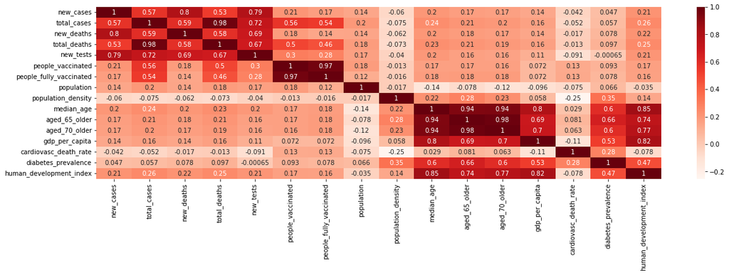

```python
plt.figure(figsize=(20,5))
cor=dataset.corr()
sns.heatmap(cor,annot=True, cmap=plt.cm.Reds)

plt.show()
```

```python
df_cases=abs(cor['total_cases'])
corelated_variables=df_cases[df_cases>0.01]

corelated_variables.sort_values(ascending=False)
```

```
total_cases                1.000000
total_deaths               0.976596
new_tests                  0.719792
new_deaths                 0.590495
new_cases                  0.565424
people_vaccinated          0.562799
people_fully_vaccinated    0.535859
human_development_index    0.256017
median_age                 0.240157
aged_65_older              0.207126
population                 0.196706
aged_70_older              0.196453
gdp_per_capita             0.162990
population_density         0.075400
diabetes_prevalence        0.057467
cardiovasc_death_rate      0.051863
Name: total_cases, dtype: float64
```

```python
dataset=dataset[['location', 'date', 'total_cases',
       'total_deaths', 'new_tests', 'people_vaccinated',
       'people_fully_vaccinated', 'population']]
dataset.head()
```

|  | location | date | total_cases | total_deaths | new_tests | people_vaccinated | people_fully_vaccinated | population |
| --- | --- | --- | --- | --- | --- | --- | --- | --- |
| 1963 | Algeria | 2/25/2020 | 1.0 | 0.0 | 0.0 | 0.0 | 0.0 | 44616626.0 |
| 1964 | Algeria | 2/26/2020 | 1.0 | 0.0 | 0.0 | 0.0 | 0.0 | 44616626.0 |
| 1965 | Algeria | 2/27/2020 | 1.0 | 0.0 | 0.0 | 0.0 | 0.0 | 44616626.0 |
| 1966 | Algeria | 2/28/2020 | 1.0 | 0.0 | 0.0 | 0.0 | 0.0 | 44616626.0 |
| 1967 | Algeria | 2/29/2020 | 1.0 | 0.0 | 0.0 | 0.0 | 0.0 | 44616626.0 |

# Grouping data based on location

```python
df3=dataset.groupby(['location']).agg({'total_cases': np.sum, 'total_deaths': np.sum,'new_tests':np.sum,
                                      'people_vaccinated':np.sum,'people_fully_vaccinated':np.sum,'population':np.sum})
df3=df3.reset_index()
df3.head()
```

|  | location | total_cases | total_deaths | new_tests | people_vaccinated | people_fully_vaccinated | population |
| --- | --- | --- | --- | --- | --- | --- | --- |
| 0 | Algeria | 62175492.0 | 1780795.0 | 0.0 | 635108101.0 | 407345399.0 | 2.900081e+10 |
| 1 | Angola | 14353725.0 | 360177.0 | 0.0 | 467859940.0 | 208103276.0 | 2.124244e+10 |
| 2 | Benin | 4436266.0 | 44177.0 | 0.0 | 25028045.0 | 15451545.0 | 7.844150e+09 |
| 3 | Botswana | 32497938.0 | 428205.0 | 19426.0 | 76906242.0 | 37602143.0 | 1.476700e+09 |
| 4 | Burkina Faso | 4937287.0 | 72411.0 | 0.0 | 28616465.0 | 19879336.0 | 1.367215e+10 |

# Ploting covid-19 detected cases accross African Countries

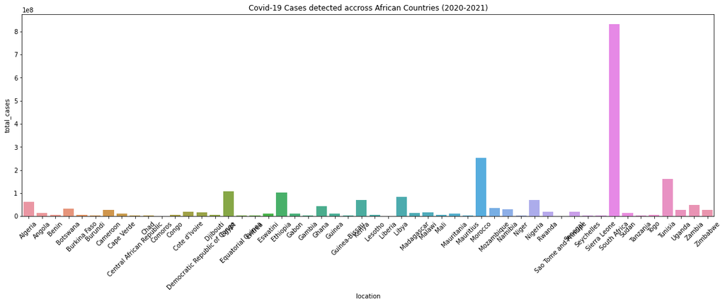

```python
plt.figure(figsize=(20,6))
plt.title("Covid-19 Cases detected accross African Countries (2020-2021)")
plt.xticks(rotation=45)
sns.barplot(x="location", y="total_cases" ,data=df3);
```

# ploting covid-19 deaths detected accross African Countries

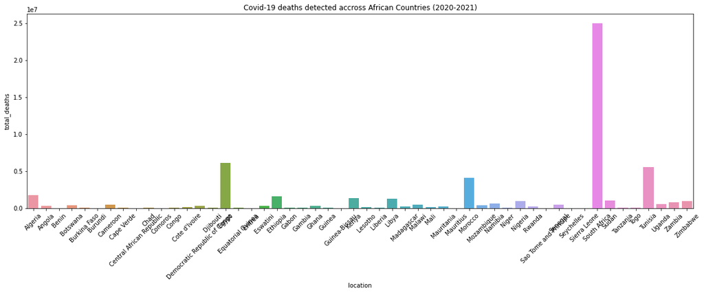

```python
plt.figure(figsize=(20,6))
plt.title("Covid-19 deaths detected accross African Countries (2020-2021)")
plt.xticks(rotation=45)
sns.barplot(x="location", y="total_deaths" ,data=df3);
```

Grouping data based on date

```python
dataset=dataset.groupby(['date']).agg({'total_cases': np.sum, 'total_deaths': np.sum,'new_tests':np.sum,
                                      'people_vaccinated':np.sum,'people_fully_vaccinated':np.sum,'population':np.sum})
```

```python
dataset.head()
```

| date | total_cases | total_deaths | new_tests | people_vaccinated | people_fully_vaccinated | population |
| --- | --- | --- | --- | --- | --- | --- |
| 1/1/2021 | 2779927.0 | 65933.0 | 97044.0 | 0.0 | 0.0 | 1.343946e+09 |
| 1/10/2021 | 3047705.0 | 72518.0 | 132582.0 | 0.0 | 0.0 | 1.343946e+09 |
| 1/11/2021 | 3075696.0 | 73199.0 | 104610.0 | 0.0 | 0.0 | 1.343946e+09 |
| 1/12/2021 | 3101753.0 | 74274.0 | 101754.0 | 0.0 | 0.0 | 1.343946e+09 |
| 1/13/2021 | 3135814.0 | 75495.0 | 125968.0 | 2000.0 | 0.0 | 1.343946e+09 |

Displaying correlation matrix of final dataset to be used

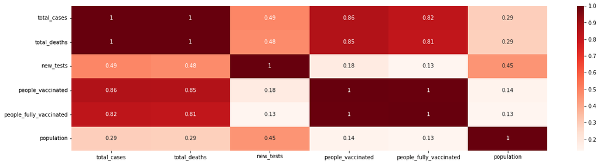

```python
plt.figure(figsize=(20,5))
cor=dataset.corr()
sns.heatmap(cor,annot=True, cmap=plt.cm.Reds)

plt.show()
```

select training variables

```python
dataset=dataset[['total_cases', 'people_vaccinated',
       'people_fully_vaccinated', 'population']]
```

```python
dataset.head()
```

| date | total_cases | people_vaccinated | people_fully_vaccinated | population |
| --- | --- | --- | --- | --- |
| 1/1/2021 | 2779927.0 | 0.0 | 0.0 | 1.343946e+09 |
| 1/10/2021 | 3047705.0 | 0.0 | 0.0 | 1.343946e+09 |
| 1/11/2021 | 3075696.0 | 0.0 | 0.0 | 1.343946e+09 |
| 1/12/2021 | 3101753.0 | 0.0 | 0.0 | 1.343946e+09 |
| 1/13/2021 | 3135814.0 | 2000.0 | 0.0 | 1.343946e+09 |